# PM2.5 Forecasting

# Density Plot of pm2.5 time series

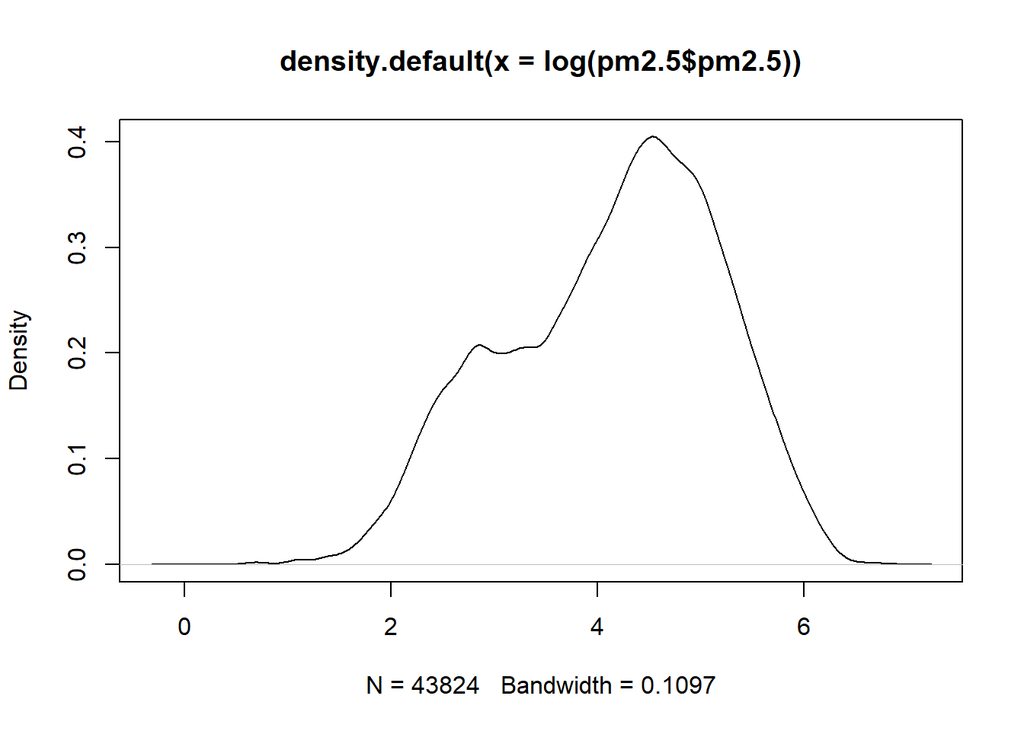

```r
plot(density(log(pm2.5$pm2.5)))
```

```r
summary(pm2.5.lm1)
```

```
##
## Call:
## lm(formula = pm2.5 ~ DEWP + TEMP + PRES + SW + NE + NW + SE,
##     data = train)
##
## Residuals:
##     Min      1Q  Median      3Q     Max
## -179.78  -52.18  -16.68   31.30  895.99
##
## Coefficients: (1 not defined because of singularities)
##               Estimate Std. Error t value Pr(>|t|)
## (Intercept) 1929.10399   85.16635  22.651   <2e-16 ***
## DEWP           4.05070    0.06076  66.670   <2e-16 ***
## TEMP          -6.31482    0.07873 -80.208   <2e-16 ***
## PRES          -1.71474    0.08324 -20.601   <2e-16 ***
## SW             0.00393    1.28336   0.003    0.998
## NE           -29.48972    1.59660 -18.470   <2e-16 ***
## NW           -40.04735    1.20423 -33.256   <2e-16 ***
## SE                  NA         NA      NA       NA
## ---
## Signif. codes:  0 '***' 0.001 '**' 0.01 '*' 0.05 '.' 0.1 ' ' 1
##
## Residual standard error: 80.45 on 30670 degrees of freedom
## Multiple R-squared:  0.239,  Adjusted R-squared:  0.2388
## F-statistic:  1605 on 6 and 30670 DF,  p-value: < 2.2e-16
```

# IHS(Inverse Hyperbolic Sine) transformation. The IHS transformation works with data defined on the whole real line including zeros. For large values of x, IHS behaves like a log transformation, and the transformation accommodates values of 0

```r
ihs <- function(x) {
  y <- log(x + sqrt(x ^ 2 + 1))
  return(y)
}
```

# Take the IHS of the response variable pm2.5

```r
pm2.5.lm1.ihs <- lm(ihs(pm2.5) ~ DEWP + TEMP + PRES + SW + NE + NW + SE, data = train)
summary(pm2.5.lm1.ihs)
```

```
##
## Call:
## lm(formula = ihs(pm2.5) ~ DEWP + TEMP + PRES + SW + NE + NW +
##     SE, data = train)
##
## Residuals:
##     Min      1Q  Median      3Q     Max
## -4.1007 -0.5456  0.0197  0.5687  3.2885
##
## Coefficients: (1 not defined because of singularities)
##               Estimate Std. Error t value Pr(>|t|)
## (Intercept) 28.1526755  0.8618829  32.664   <2e-16 ***
## DEWP         0.0544473  0.0006149  88.551   <2e-16 ***
## TEMP        -0.0759813  0.0007968 -95.364   <2e-16 ***
## PRES        -0.0217879  0.0008423 -25.866   <2e-16 ***
## SW          -0.1175254  0.0129876  -9.049   <2e-16 ***
## NE          -0.5566304  0.0161575 -34.450   <2e-16 ***
## NW          -0.7411186  0.0121868 -60.813   <2e-16 ***
## SE                  NA         NA      NA       NA
## ---
## Signif. codes:  0 '***' 0.001 '**' 0.01 '*' 0.05 '.' 0.1 ' ' 1
##
## Residual standard error: 0.8141 on 30670 degrees of freedom
## Multiple R-squared:  0.3752, Adjusted R-squared:  0.3751
## F-statistic:  3070 on 6 and 30670 DF,  p-value: < 2.2e-16
```

# Diagnose the model

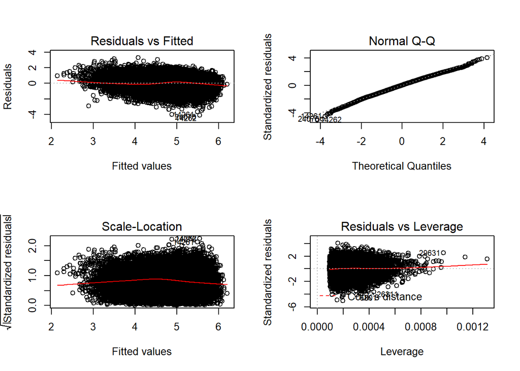

```r
par(mfrow = c(2,2))
plot(pm2.5.lm1.ihs)
```

```r
par(mfrow = c(1,1))
save_data <- c()
for(i in 1:1000){
  result_test <- shapiro.test(sample(pm2.5.lm1.ihs$residuals,5000))
  save_data <- append(save_data,result_test[[2]])
}
length(save_data[save_data<=0.05])
```

```
## [1] 1000
```

# From the Normal Q-Q plot, we get that the residual is nealy normally distributed. So we can say that the ihs transformation rastically increased the adjusted R 2 and significantly improved the model assumptions.

# Build a main effects + interation model

```r
pm2.5.lm2 <- lm(pm2.5 ~ (DEWP + TEMP +
    PRES + SW + NE + NW + SE)^2, data = train)
summary(pm2.5.lm2)
```

```
##
## Call:
## lm(formula = pm2.5 ~ (DEWP + TEMP + PRES + SW + NE + NW + SE)^2,
##     data = train)
##
## Residuals:
##     Min      1Q  Median      3Q     Max
## -182.49  -50.13  -14.48   31.46  922.83
##
## Coefficients: (10 not defined because of singularities)
##               Estimate Std. Error t value Pr(>|t|)
## (Intercept)  9.371e+02  1.841e+02   5.089 3.62e-07 ***
## DEWP        -1.256e+02  7.359e+00 -17.068  < 2e-16 ***
## TEMP         5.963e+01  7.255e+00   8.219  < 2e-16 ***
## PRES        -7.364e-01  1.802e-01  -4.086 4.39e-05 ***
## SW          -1.262e+01  2.343e+02  -0.054 0.957033
## NE           4.415e+02  2.945e+02   1.499 0.133835
## NW           5.673e+02  2.176e+02   2.607 0.009150 **
## SE                  NA         NA      NA       NA
## DEWP:TEMP   -4.435e-02  6.266e-03  -7.078 1.49e-12 ***
## DEWP:PRES    1.284e-01  7.205e-03  17.818  < 2e-16 ***
## DEWP:SW      2.666e-01  1.845e-01   1.445 0.148582
## DEWP:NE      3.434e-01  2.105e-01   1.631 0.102945
## DEWP:NW     -5.467e-01  1.447e-01  -3.777 0.000159 ***
## DEWP:SE             NA         NA      NA       NA
## TEMP:PRES   -6.426e-02  7.146e-03  -8.992  < 2e-16 ***
## TEMP:SW     -1.369e+00  2.245e-01  -6.101 1.07e-09 ***
## TEMP:NE     -1.526e+00  2.727e-01  -5.596 2.21e-08 ***
## TEMP:NW     -1.004e+00  1.976e-01  -5.082 3.77e-07 ***
## TEMP:SE             NA         NA      NA       NA
## PRES:SW      2.893e-02  2.291e-01   0.126 0.899517
## PRES:NE     -4.398e-01  2.878e-01  -1.528 0.126442
## PRES:NW     -5.820e-01  2.127e-01  -2.737 0.006210 **
## PRES:SE             NA         NA      NA       NA
## SW:NE               NA         NA      NA       NA
## SW:NW               NA         NA      NA       NA
## SW:SE               NA         NA      NA       NA
## NE:NW               NA         NA      NA       NA
## NE:SE               NA         NA      NA       NA
## NW:SE               NA         NA      NA       NA
## ---
## Signif. codes:  0 '***' 0.001 '**' 0.01 '*' 0.05 '.' 0.1 ' ' 1
##
## Residual standard error: 78.73 on 30658 degrees of freedom
## Multiple R-squared:  0.2713, Adjusted R-squared:  0.2709
## F-statistic: 634.2 on 18 and 30658 DF,  p-value: < 2.2e-16
```

# Diagnose the mdoel

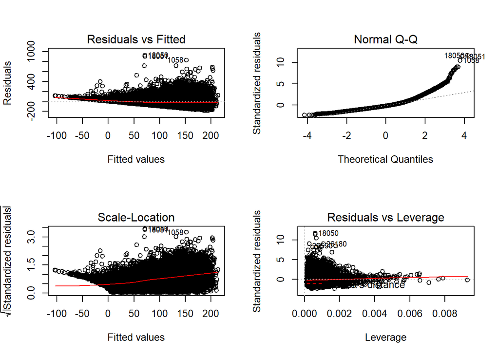

```r
par(mfrow = c(2,2))
plot(pm2.5.lm2)
```

```r
par(mfrow = c(1,1))
save_data <- c()
for(i in 1:1000){
  result_test <- shapiro.test(sample(pm2.5.lm2$residuals,5000))
  save_data <- append(save_data,result_test[[2]])
}
length(save_data[save_data<=0.05])
```

```
## [1] 1000
```

# From the Normal Q-Q plot and the shapiro test result, we know that the residuals are not normally distributed. So we need do IHS(Inverse Hyperbolic Sine) transformation

# Take the IHS of the response variable pm2.5

```r
pm2.5.lm2.ihs <- lm(ihs(pm2.5) ~ (DEWP + TEMP +
    PRES + SW + NE + NW + SE)^2, data = train)
summary(pm2.5.lm2.ihs)
```

```
##
## Call:
## lm(formula = ihs(pm2.5) ~ (DEWP + TEMP + PRES + SW + NE + NW +
##     SE)^2, data = train)
##
## Residuals:
##     Min      1Q  Median      3Q     Max
## -4.1870 -0.5124  0.0384  0.5562  3.5788
##
## Coefficients: (10 not defined because of singularities)
##               Estimate Std. Error t value Pr(>|t|)
## (Intercept)  1.529e+01  1.851e+00   8.260  < 2e-16 ***
## DEWP        -1.636e+00  7.397e-02 -22.115  < 2e-16 ***
## TEMP         5.926e-01  7.292e-02   8.126 4.61e-16 ***
## PRES        -9.209e-03  1.811e-03  -5.084 3.72e-07 ***
## SW          -1.410e+00  2.355e+00  -0.599 0.549412
## NE           1.025e+01  2.960e+00   3.461 0.000539 ***
## NW           1.182e+01  2.188e+00   5.405 6.53e-08 ***
## SE                  NA         NA      NA       NA
## DEWP:TEMP   -4.777e-05  6.298e-05  -0.758 0.448183
## DEWP:PRES    1.657e-03  7.242e-05  22.886  < 2e-16 ***
## DEWP:SW      5.755e-03  1.855e-03   3.102 0.001921 **
## DEWP:NE      1.867e-02  2.116e-03   8.822  < 2e-16 ***
## DEWP:NW      9.374e-03  1.455e-03   6.444 1.18e-10 ***
## DEWP:SE             NA         NA      NA       NA
## TEMP:PRES   -6.426e-04  7.183e-05  -8.946  < 2e-16 ***
## TEMP:SW     -1.337e-02  2.256e-03  -5.927 3.11e-09 ***
## TEMP:NE     -3.225e-02  2.742e-03 -11.763  < 2e-16 ***
## TEMP:NW     -2.608e-02  1.986e-03 -13.132  < 2e-16 ***
## TEMP:SE             NA         NA      NA       NA
## PRES:SW      1.435e-03  2.303e-03   0.623 0.533252
## PRES:NE     -1.022e-02  2.893e-03  -3.532 0.000412 ***
## PRES:NW     -1.203e-02  2.138e-03  -5.626 1.87e-08 ***
## PRES:SE             NA         NA      NA       NA
## SW:NE               NA         NA      NA       NA
## SW:NW               NA         NA      NA       NA
## SW:SE               NA         NA      NA       NA
## NE:NW               NA         NA      NA       NA
## NE:SE               NA         NA      NA       NA
## NW:SE               NA         NA      NA       NA
## ---
## Signif. codes:  0 '***' 0.001 '**' 0.01 '*' 0.05 '.' 0.1 ' ' 1
##
## Residual standard error: 0.7914 on 30658 degrees of freedom
## Multiple R-squared:  0.4098, Adjusted R-squared:  0.4095
## F-statistic:  1183 on 18 and 30658 DF,  p-value: < 2.2e-16
```

# Test the model

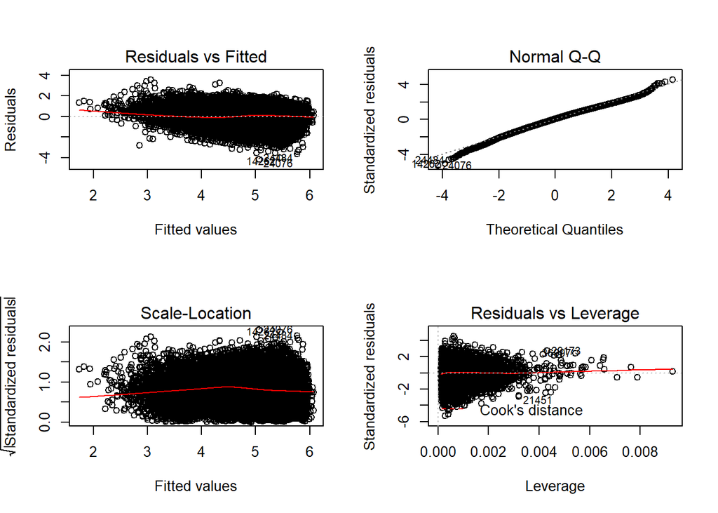

```r
par(mfrow = c(2,2))
plot(pm2.5.lm2.ihs)
```

```r
par(mfrow = c(1,1))
save_data <- c()
for(i in 1:1000){
  result_test <- shapiro.test(sample(pm2.5.lm2.ihs$residuals,5000))
  save_data <- append(save_data,result_test[[2]])
}
length(save_data[save_data<=0.05])
```

```
## [1] 1000
```

# The residual of pm2.5.lm.ihs is nearly normally distributed and significantly improve the model assumption

# Use stepwise regressio on your main effects + interation model

```r
pm2.5.lm2.step <- step(pm2.5.lm2.ihs)
```

```
## Start:  AIC=-14334.99
## ihs(pm2.5) ~ (DEWP + TEMP + PRES + SW + NE + NW + SE)^2
##
##
## Step:  AIC=-14334.99
## ihs(pm2.5) ~ DEWP + TEMP + PRES + SW + NE + NW + SE + DEWP:TEMP +
##     DEWP:PRES + DEWP:SW + DEWP:NE + DEWP:NW + DEWP:SE + TEMP:PRES +
##     TEMP:SW + TEMP:NE + TEMP:NW + TEMP:SE + PRES:SW + PRES:NE +
##     PRES:NW + PRES:SE + SW:NE + SW:NW + SW:SE + NE:NW + NE:SE
##
##
## Step:  AIC=-14334.99
## ihs(pm2.5) ~ DEWP + TEMP + PRES + SW + NE + NW + SE + DEWP:TEMP +
##     DEWP:PRES + DEWP:SW + DEWP:NE + DEWP:NW + DEWP:SE + TEMP:PRES +
##     TEMP:SW + TEMP:NE + TEMP:NW + TEMP:SE + PRES:SW + PRES:NE +
##     PRES:NW + PRES:SE + SW:NE + SW:NW + SW:SE + NE:NW
##
##
## Step:  AIC=-14334.99
## ihs(pm2.5) ~ DEWP + TEMP + PRES + SW + NE + NW + SE + DEWP:TEMP +
##     DEWP:PRES + DEWP:SW + DEWP:NE + DEWP:NW + DEWP:SE + TEMP:PRES +
##     TEMP:SW + TEMP:NE + TEMP:NW + TEMP:SE + PRES:SW + PRES:NE +
##     PRES:NW + PRES:SE + SW:NE + SW:NW + SW:SE
##
##
## Step:  AIC=-14334.99
## ihs(pm2.5) ~ DEWP + TEMP + PRES + SW + NE + NW + SE + DEWP:TEMP +
##     DEWP:PRES + DEWP:SW + DEWP:NE + DEWP:NW + DEWP:SE + TEMP:PRES +
##     TEMP:SW + TEMP:NE + TEMP:NW + TEMP:SE + PRES:SW + PRES:NE +
##     PRES:NW + PRES:SE + SW:NE + SW:NW
##
##
## Step:  AIC=-14334.99
## ihs(pm2.5) ~ DEWP + TEMP + PRES + SW + NE + NW + SE + DEWP:TEMP +
##     DEWP:PRES + DEWP:SW + DEWP:NE + DEWP:NW + DEWP:SE + TEMP:PRES +
##     TEMP:SW + TEMP:NE + TEMP:NW + TEMP:SE + PRES:SW + PRES:NE +
##     PRES:NW + PRES:SE + SW:NE
##
##
## Step:  AIC=-14334.99
```

[output cut: 66 more lines]

```
##     DEWP:SW + DEWP:NE + DEWP:NW + TEMP:PRES + TEMP:SW + TEMP:NE +
##     TEMP:NW + PRES:NE + PRES:NW
##
##             Df Sum of Sq   RSS    AIC
## <none>                   19202 -14338
## - DEWP:SW    1      6.06 19208 -14330
## - PRES:NE    1      9.90 19212 -14324
## - DEWP:NW    1     26.98 19229 -14297
## - PRES:NW    1     28.98 19231 -14294
## - TEMP:SW    1     30.20 19232 -14292
## - DEWP:NE    1     49.22 19251 -14261
## - TEMP:PRES  1     52.89 19255 -14256
## - TEMP:NE    1     91.43 19294 -14194
## - TEMP:NW    1    123.50 19326 -14143
## - DEWP:PRES  1    475.98 19678 -13589
```